# Bank Marketing Campaign

Fauzan Alamsyah

2/13/2021

Before going through this project file, you may want to see the *Libraries and Setup* page to see what kind of setup and libraries I’m using. I also texted down my *objective* of this project.

# 1 Background

## 1.1 About Dataset

The data is related with direct marketing campaigns of a Portuguese banking institution. The marketing campaigns were based on phone calls. The bank is trying to ask its client for a term deposit during this campaign.

The data set itself contains its client record information, their balance, and their last phone call’s campaign in the year of 2010. Though it’s a record of client’s data information in the past campaign, the proportion of the outcome isn’t properly balance. That’s why, at the end I can’t really conclude the best explanation for insights.

I got this data frome here, https://archive.ics.uci.edu/ml/datasets/bank+marketing

## 1.2 Libraries and Setup

```r
# chunk set up
knitr::opts_chunk$set(cache=TRUE,
                      fig.align = "center",
                      comment = "#>"
                      )

# set up scientific notation
options(scipen = 9999)

# clear Global Environment
rm(list=ls())
```

```r
# Library I use
library(dplyr)
library(knitr)
```

## 1.3 Objective

This is a Learn By Building (LBB) project by me as a student at Algoritma Data Science Academy. I’m currently new to this job world, so you may find some of my deficiencies in analyzing this data.

# 2 Data Wrangling

```r
bank <- read.csv2("data_input/bank-full.csv")
```

## 2.1 Data Inspection

```r
head(bank)
```

```
#>   age          job marital education default balance housing loan contact day
#> 1  58   management married  tertiary      no    2143     yes   no unknown   5
#> 2  44   technician  single secondary      no      29     yes   no unknown   5
#> 3  33 entrepreneur married secondary      no       2     yes  yes unknown   5
#> 4  47  blue-collar married   unknown      no    1506     yes   no unknown   5
#> 5  33      unknown  single   unknown      no       1      no   no unknown   5
#> 6  35   management married  tertiary      no     231     yes   no unknown   5
#>   month duration campaign pdays previous poutcome  y
#> 1   may      261        1    -1        0  unknown no
#> 2   may      151        1    -1        0  unknown no
#> 3   may       76        1    -1        0  unknown no
#> 4   may       92        1    -1        0  unknown no
#> 5   may      198        1    -1        0  unknown no
#> 6   may      139        1    -1        0  unknown no
```

```r
str(bank)
```

```
#> 'data.frame':    45211 obs. of  17 variables:
#>  $ age      : int  58 44 33 47 33 35 28 42 58 43 ...
#>  $ job      : chr  "management" "technician" "entrepreneur" "blue-collar" ...
#>  $ marital  : chr  "married" "single" "married" "married" ...
#>  $ education: chr  "tertiary" "secondary" "secondary" "unknown" ...
#>  $ default  : chr  "no" "no" "no" "no" ...
#>  $ balance  : int  2143 29 2 1506 1 231 447 2 121 593 ...
#>  $ housing  : chr  "yes" "yes" "yes" "yes" ...
#>  $ loan     : chr  "no" "no" "yes" "no" ...
#>  $ contact  : chr  "unknown" "unknown" "unknown" "unknown" ...
#>  $ day      : int  5 5 5 5 5 5 5 5 5 5 ...
#>  $ month    : chr  "may" "may" "may" "may" ...
#>  $ duration : int  261 151 76 92 198 139 217 380 50 55 ...
#>  $ campaign : int  1 1 1 1 1 1 1 1 1 1 ...
#>  $ pdays    : int  -1 -1 -1 -1 -1 -1 -1 -1 -1 -1 ...
#>  $ previous : int  0 0 0 0 0 0 0 0 0 0 ...
#>  $ poutcome : chr  "unknown" "unknown" "unknown" "unknown" ...
#>  $ y        : chr  "no" "no" "no" "no" ...
```

```r
colSums(is.na(bank))
```

```
#>       age       job   marital education   default   balance   housing      loan
#>         0         0         0         0         0         0         0         0
#>   contact       day     month  duration  campaign     pdays  previous  poutcome
#>         0         0         0         0         0         0         0         0
#>         y
#>         0
```

As it seems there are no missing values in the data frame, and that makes easier to analyze deeper. I likely should do some of data transformation so that the data is fully prepared.

## 2.2 Data Transformation

Some type of variables don’t match as they should be. Therefore, all of the *character* types must be change to *factor*, because each of them have quite some categorical levels.

```r
bank <- bank %>%
  mutate_if(is.character, as.factor) %>%
  mutate(month = as.character(month))
```

The reason why I put back *month* variable to what it was is because *day* variable written as integer which actually these integers represent date of month. By putting back *month* variable to *character* type, I could transform the integer in *day* to name of weekdays.

```r
bank <- bank %>%
  mutate(year = 2010)

bank <- bank %>%
  mutate(date = paste(year,month,day,sep = "-"))

bank$date <- as.POSIXct(bank$date, format = "%Y-%b-%d")

bank <- bank %>%
  mutate(day = weekdays(bank$date,abbreviate = TRUE)) %>%
  mutate(day = as.factor(day))
```

Since I don’t really need *year* and *date* variable, I would remove these two.

```r
bank <- bank %>%
  mutate(month = as.factor(month)) %>%
  select(-c(year, date))
```

```r
kable(bank[1:6,], caption = "Bank Markteing Campaign Data Set")
```

Bank Markteing Campaign Data Set

| age | job | marital | education | default | balance | housing | loan | contact | day | month | duration | campaign | pdays | previous | poutcome | y |
| --- | --- | --- | --- | --- | --- | --- | --- | --- | --- | --- | --- | --- | --- | --- | --- | --- |
| 58 | management | married | tertiary | no | 2143 | yes | no | unknown | Wed | may | 261 | 1 | -1 | 0 | unknown | no |
| 44 | technician | single | secondary | no | 29 | yes | no | unknown | Wed | may | 151 | 1 | -1 | 0 | unknown | no |
| 33 | entrepreneur | married | secondary | no | 2 | yes | yes | unknown | Wed | may | 76 | 1 | -1 | 0 | unknown | no |
| 47 | blue-collar | married | unknown | no | 1506 | yes | no | unknown | Wed | may | 92 | 1 | -1 | 0 | unknown | no |
| 33 | unknown | single | unknown | no | 1 | no | no | unknown | Wed | may | 198 | 1 | -1 | 0 | unknown | no |
| 35 | management | married | tertiary | no | 231 | yes | no | unknown | Wed | may | 139 | 1 | -1 | 0 | unknown | no |

and yet I’m finished with transforming the data.

# 3 Exploratory Data Analysis

First we look ahead for the summary of the data

```r
summary(bank)
```

```
#>       age                 job           marital          education
#>  Min.   :18.00   blue-collar:9732   divorced: 5207   primary  : 6851
#>  1st Qu.:33.00   management :9458   married :27214   secondary:23202
#>  Median :39.00   technician :7597   single  :12790   tertiary :13301
#>  Mean   :40.94   admin.     :5171                    unknown  : 1857
#>  3rd Qu.:48.00   services   :4154
#>  Max.   :95.00   retired    :2264
#>                  (Other)    :6835
#>  default        balance       housing      loan            contact
#>  no :44396   Min.   : -8019   no :20081   no :37967   cellular :29285
#>  yes:  815   1st Qu.:    72   yes:25130   yes: 7244   telephone: 2906
#>              Median :   448                           unknown  :13020
#>              Mean   :  1362
#>              3rd Qu.:  1428
#>              Max.   :102127
#>
#>   day           month          duration         campaign          pdays
#>  Fri:9493   may    :13766   Min.   :   0.0   Min.   : 1.000   Min.   : -1.0
#>  Mon: 562   jul    : 6895   1st Qu.: 103.0   1st Qu.: 1.000   1st Qu.: -1.0
#>  Sat:8647   aug    : 6247   Median : 180.0   Median : 2.000   Median : -1.0
#>  Sun:5394   jun    : 5341   Mean   : 258.2   Mean   : 2.764   Mean   : 40.2
#>  Thu:8895   nov    : 3970   3rd Qu.: 319.0   3rd Qu.: 3.000   3rd Qu.: -1.0
#>  Tue:4064   apr    : 2932   Max.   :4918.0   Max.   :63.000   Max.   :871.0
#>  Wed:8156   (Other): 6060
#>     previous           poutcome       y
#>  Min.   :  0.0000   failure: 4901   no :39922
#>  1st Qu.:  0.0000   other  : 1840   yes: 5289
#>  Median :  0.0000   success: 1511
#>  Mean   :  0.5803   unknown:36959
#>  3rd Qu.:  0.0000
#>  Max.   :275.0000
#>
```

```r
prop.table(table(bank$y))
```

```
#>
#>        no       yes
#> 0.8830152 0.1169848
```

That being said, the proportion of the outcome if the data isn’t heavily balanced, as it’s 1:9. I’m going to try my best to come up for acceptable insights. For that, the exploration will just focus on the ‘positive’ outcome.

```r
bank_yes <- bank %>%
  filter(y == "yes")

bank_no <- bank %>%
  filter(y == "no")
```

```r
summary(bank_yes)
```

```
#>       age                 job           marital         education    default
#>  Min.   :18.00   management :1301   divorced: 622   primary  : 591   no :5237
#>  1st Qu.:31.00   technician : 840   married :2755   secondary:2450   yes:  52
#>  Median :38.00   blue-collar: 708   single  :1912   tertiary :1996
#>  Mean   :41.67   admin.     : 631                   unknown  : 252
#>  3rd Qu.:50.00   retired    : 516
#>  Max.   :95.00   services   : 369
#>                  (Other)    : 924
#>     balance      housing     loan           contact      day
#>  Min.   :-3058   no :3354   no :4805   cellular :4369   Fri:1123
#>  1st Qu.:  210   yes:1935   yes: 484   telephone: 390   Mon: 233
#>  Median :  733                         unknown  : 530   Sat: 770
#>  Mean   : 1804                                          Sun: 302
#>  3rd Qu.: 2159                                          Thu:1062
#>  Max.   :81204                                          Tue: 788
#>                                                         Wed:1011
#>      month         duration         campaign          pdays
#>  may    : 925   Min.   :   8.0   Min.   : 1.000   Min.   : -1.0
#>  aug    : 688   1st Qu.: 244.0   1st Qu.: 1.000   1st Qu.: -1.0
#>  jul    : 627   Median : 426.0   Median : 2.000   Median : -1.0
#>  apr    : 577   Mean   : 537.3   Mean   : 2.141   Mean   : 68.7
#>  jun    : 546   3rd Qu.: 725.0   3rd Qu.: 3.000   3rd Qu.: 98.0
#>  feb    : 441   Max.   :3881.0   Max.   :32.000   Max.   :854.0
#>  (Other):1485
#>     previous        poutcome      y
#>  Min.   : 0.00   failure: 618   no :   0
#>  1st Qu.: 0.00   other  : 307   yes:5289
#>  Median : 0.00   success: 978
#>  Mean   : 1.17   unknown:3386
#>  3rd Qu.: 1.00
#>  Max.   :58.00
#>
```

```r
summary(bank_no)
```

```
#>       age                 job           marital          education
#>  Min.   :18.00   blue-collar:9024   divorced: 4585   primary  : 6260
#>  1st Qu.:33.00   management :8157   married :24459   secondary:20752
#>  Median :39.00   technician :6757   single  :10878   tertiary :11305
#>  Mean   :40.84   admin.     :4540                    unknown  : 1605
#>  3rd Qu.:48.00   services   :3785
#>  Max.   :95.00   retired    :1748
#>                  (Other)    :5911
#>  default        balance       housing      loan            contact
#>  no :39159   Min.   : -8019   no :16727   no :33162   cellular :24916
#>  yes:  763   1st Qu.:    58   yes:23195   yes: 6760   telephone: 2516
#>              Median :   417                           unknown  :12490
#>              Mean   :  1304
#>              3rd Qu.:  1345
#>              Max.   :102127
#>
#>   day           month          duration         campaign          pdays
#>  Fri:8370   may    :12841   Min.   :   0.0   Min.   : 1.000   Min.   : -1.00
#>  Mon: 329   jul    : 6268   1st Qu.:  95.0   1st Qu.: 1.000   1st Qu.: -1.00
#>  Sat:7877   aug    : 5559   Median : 164.0   Median : 2.000   Median : -1.00
#>  Sun:5092   jun    : 4795   Mean   : 221.2   Mean   : 2.846   Mean   : 36.42
#>  Thu:7833   nov    : 3567   3rd Qu.: 279.0   3rd Qu.: 3.000   3rd Qu.: -1.00
#>  Tue:3276   apr    : 2355   Max.   :4918.0   Max.   :63.000   Max.   :871.00
#>  Wed:7145   (Other): 4537
#>     previous           poutcome       y
#>  Min.   :  0.0000   failure: 4283   no :39922
#>  1st Qu.:  0.0000   other  : 1533   yes:    0
#>  Median :  0.0000   success:  533
#>  Mean   :  0.5021   unknown:33573
#>  3rd Qu.:  0.0000
#>  Max.   :275.0000
#>
```

Here comes some questions,

**1. What kind of job does a person who agreed with the term deposit campaign have in the background? And what is their status marital?**

```r
table(bank_yes$job, bank_yes$marital)
```

```
#>
#>                 divorced married single
#>   admin.              90     306    235
#>   blue-collar         58     437    213
#>   entrepreneur        15      81     27
#>   housemaid           18      67     24
#>   management         142     681    478
#>   retired            121     382     13
#>   self-employed       22      79     86
#>   services            50     178    141
#>   student              1      10    258
#>   technician          77     416    347
#>   unemployed          27      97     78
#>   unknown              1      21     12
```

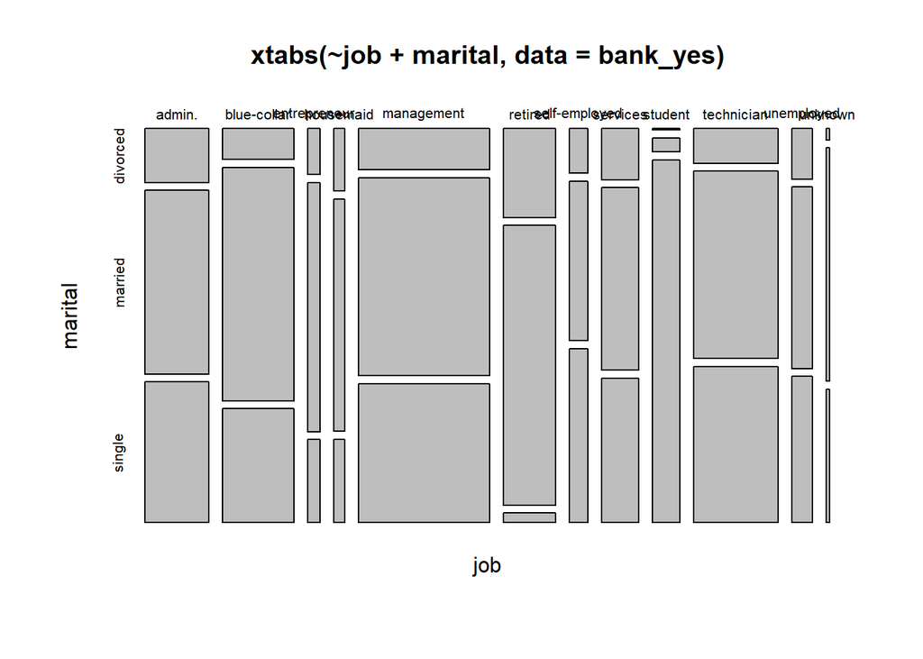

```r
plot(xtabs(~ job + marital, data = bank_yes))
```

**2. Does educational background have any correlation to client’s outcome?**

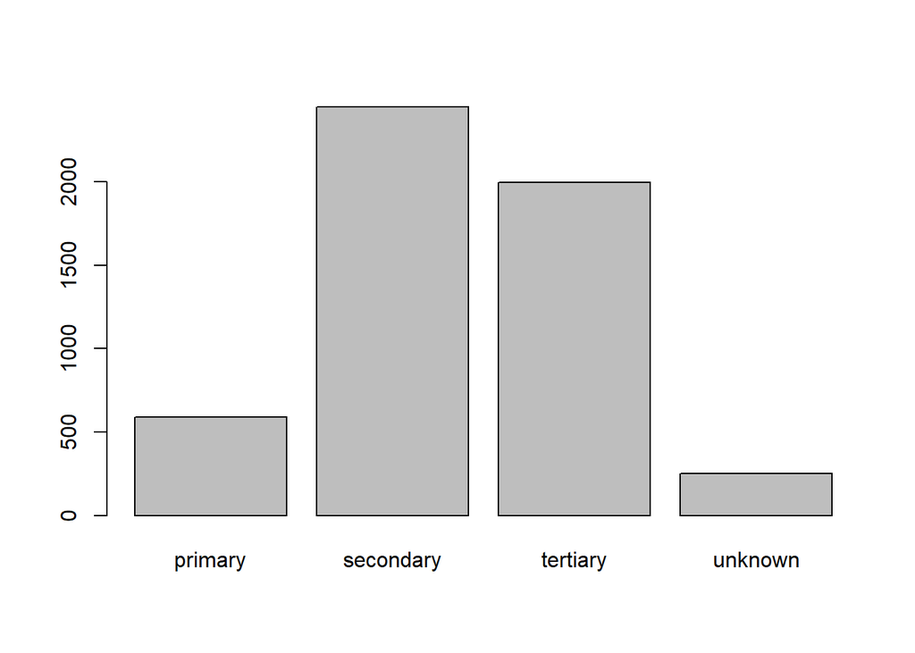

```r
#Positive outcome
plot(bank_yes$education)
```

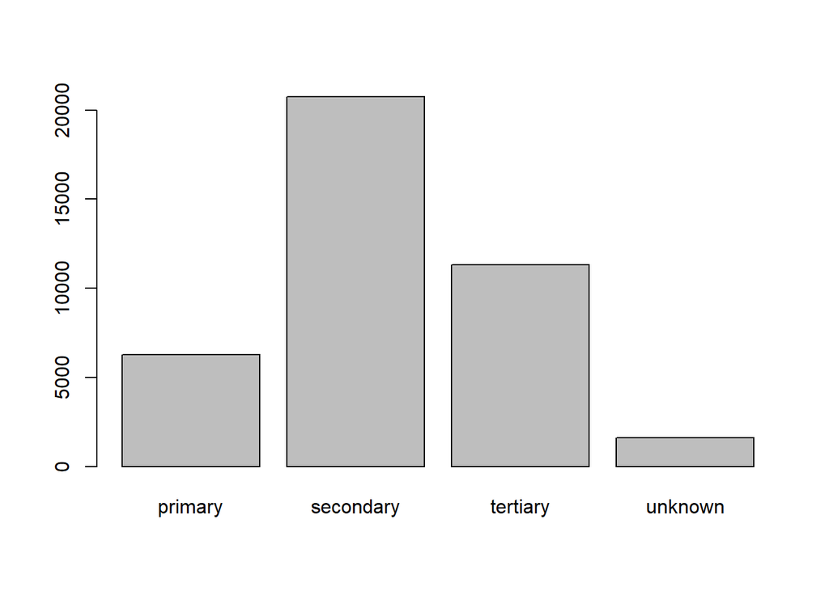

```r
#Negative outcome
plot(bank_no$education)
```

**3. How about default credit and loans?**

For default credit,

```r
#Positive outcome
table(bank_yes$default)
```

```
#>
#>   no  yes
#> 5237   52
```

```r
#Negative outcome
table(bank_no$default)
```

```
#>
#>    no   yes
#> 39159   763
```

For Housing loan,

```r
#Positive outcome
table(bank_yes$housing)
```

```
#>
#>   no  yes
#> 3354 1935
```

```r
#Negative outcome
table(bank_no$housing)
```

```
#>
#>    no   yes
#> 16727 23195
```

For other loans,

```r
#Positive outcome
table(bank_yes$loan)
```

```
#>
#>   no  yes
#> 4805  484
```

```r
#Negative outcome
table(bank_no$loan)
```

```
#>
#>    no   yes
#> 33162  6760
```

**4. Client’s balance?**

```r
#Positive outcome
summary(bank_yes$balance)
```

```
#>    Min. 1st Qu.  Median    Mean 3rd Qu.    Max.
#>   -3058     210     733    1804    2159   81204
```

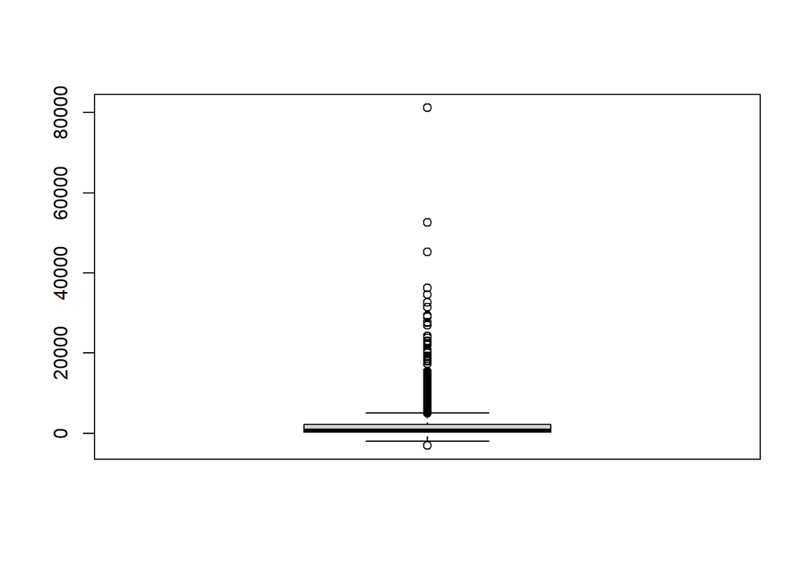

```r
boxplot(bank_yes$balance)
```

```r
#Negative outcome
summary(bank_no$balance)
```

```
#>    Min. 1st Qu.  Median    Mean 3rd Qu.    Max.
#>   -8019      58     417    1304    1345  102127
```

# 4 Conclusion and Marketing Strategy Recomendation